# DATA589_Project

## Initial Coordinates Plotting

```r
# convert cleaned_asc_bc to SpatialPointsDataFrame-class
#reference: https://www.nceas.ucsb.edu/sites/default/files/2020-04/OverviewCoordinateReferenceSystems.pdf
#           https://scisus.org/2014/05/

names(cleaned_asc_bc)
```

```
##  [1] "decimalLongitude"              "decimalLatitude"
##  [3] "order"                         "family"
##  [5] "genus"                         "species"
##  [7] "genericName"                   "specificEpithet"
##  [9] "coordinateUncertaintyInMeters" "stateProvince"
## [11] "year"                          "month"
## [13] "day"                           "eventDate"
## [15] "occurrenceStatus"              "class"
## [17] "countryCode"                   "country"
## [19] "verbatimLocality"              "taxonID"
## [21] "catalogNumber"                 "institutionCode"
## [23] "eventTime"                     "verbatimEventDate"
## [25] "collectionCode"                "gbifID"
## [27] "verbatimLocality.1"
```

```r
sort(unique(cleaned_asc_bc$individualCount))  # notice if some points correspond to zero abundance
```

```r
sort(unique(cleaned_asc_bc$occurrenceStatus))  # check for different indications of "absent", which could be in different languages
```

```
## [1] "PRESENT"
```

```r
absence_rows <- which(cleaned_asc_bc$individualCount == 0 | cleaned_asc_bc$occurrenceStatus %in% c("absent", "Absent", "ABSENT", "ausente", "Ausente", "AUSENTE"))
length(absence_rows)
```

```
## [1] 0
```

```r
if (length(absence_rows) > 0) {
  cleaned_asc_bc <- cleaned_asc_bc[-absence_rows, ]
}

library(sp)
sp_asc_bc <- SpatialPointsDataFrame(coords = cleaned_asc_bc[, c("decimalLongitude", "decimalLatitude")],
                                         data = cleaned_asc_bc)


proj4string(sp_asc_bc) <- CRS("+proj=longlat +datum=WGS84")

# install.packages("rgdal")
library(rgdal)
#project basemap to match spu shapefile
tran_sp_asc_bc <- spTransform(sp_asc_bc, CRS("+proj=aea +lat_0=45 +lon_0=-126 +lat_1=50 +lat_2=58.5 +x_0=1000000 +y_0=0 +datum=NAD83 +units=m +no_defs"))
summary(tran_sp_asc_bc)
```

```
## Object of class SpatialPointsDataFrame
## Coordinates:
##                       min     max
## decimalLongitude 606101.5 1798367
## decimalLatitude  370250.1 1007523
## Is projected: TRUE
## proj4string :
## [+proj=aea +lat_0=45 +lon_0=-126 +lat_1=50 +lat_2=58.5 +x_0=1000000
## +y_0=0 +datum=NAD83 +units=m +no_defs]
## Number of points: 500
## Data attributes:
##  decimalLongitude decimalLatitude    order              family
##  Min.   :-131.9   Min.   :48.32   Length:500         Length:500
##  1st Qu.:-123.5   1st Qu.:48.43   Class :character   Class :character
##  Median :-123.5   Median :48.46   Mode  :character   Mode  :character
##  Mean   :-123.4   Mean   :48.72
##  3rd Qu.:-123.4   3rd Qu.:48.80
##  Max.   :-114.9   Max.   :54.04
##
##     genus             species          genericName        specificEpithet
##  Length:500         Length:500         Length:500         Length:500
##  Class :character   Class :character   Class :character   Class :character
##  Mode  :character   Mode  :character   Mode  :character   Mode  :character
##
##
##
##
##  coordinateUncertaintyInMeters stateProvince           year          month
##  Min.   :     1.0              Length:500         Min.   :2023   Min.   :1
##  1st Qu.:     5.0              Class :character   1st Qu.:2023   1st Qu.:1
##  Median :     8.0              Mode  :character   Median :2023   Median :1
##  Mean   :   554.4                                 Mean   :2023   Mean   :1
##  3rd Qu.:    26.0                                 3rd Qu.:2023   3rd Qu.:1
##  Max.   :111003.0                                 Max.   :2023   Max.   :1
##  NA's   :98
##       day         eventDate         occurrenceStatus      class
##  Min.   : 1.00   Length:500         Length:500         Length:500
##  1st Qu.: 9.75   Class :character   Class :character   Class :character
##  Median :23.00   Mode  :character   Mode  :character   Mode  :character
##  Mean   :18.74
```

[output cut: 12 more lines]

```
##  Min.   :145614607   Length:500         Length:500         Length:500
##  1st Qu.:146308188   Class :character   Class :character   Class :character
##  Median :147241211   Mode  :character   Mode  :character   Mode  :character
##  Mean   :146966921
##  3rd Qu.:147567074
##  Max.   :147668848
##
##  collectionCode         gbifID          verbatimLocality.1
##  Length:500         Min.   :4.011e+09   Length:500
##  Class :character   1st Qu.:4.018e+09   Class :character
##  Mode  :character   Median :4.029e+09   Mode  :character
##                     Mean   :4.026e+09
##                     3rd Qu.:4.029e+09
##                     Max.   :4.076e+09
##
```

```r
#update to spTransformed Longitude & Latitude
cleaned_asc_bc$decimalLongitude <- tran_sp_asc_bc@coords[, 1]
cleaned_asc_bc$decimalLatitude <- tran_sp_asc_bc@coords[, 2]

# save the data as CSV
write.csv(cleaned_asc_bc, "data/clean_sp_asc_bc", row.names = FALSE)
cleaned_asc_bc <- read.csv("data/clean_sp_asc_bc")

#plot(decimalLatitude ~ decimalLongitude,
#     pch = 16,
#     col = "#046C9A",
#     data = cleaned_asc_bc)
```

```r
library(spatstat)
```

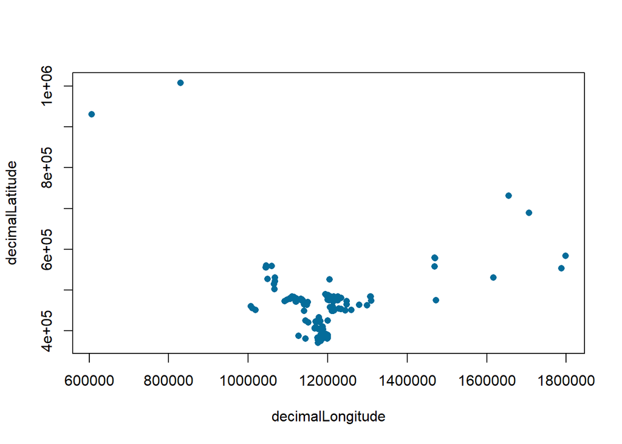

```r
# install.packages("maptools")
library(maptools)
#Visualise the data
plot(decimalLatitude ~ decimalLongitude,
     pch = 16,
     col = "#046C9A",
     data = cleaned_asc_bc)
```

From the initial coordinate plot, we have identified the following very preliminary observation : - Points clustering is highly likely as a large group of data points is spotted at the decimal Longitude between 1000K and 1300K and Latitude between 4e+5 and 5e+5. - Therefore is only a single major and significant large clustering only. Although there are some other scattered points observed near the Longitude range 1500K-1800K, they are simply incomparable to the large clustering.

## BC Windows Data Walkthough

Let’s see what the BC_Covariates.Rda file provide us which may help us to identify and choose appropriate fields to be used in the covariates analysis in the later part of this analysis. It should contain the information on the BC province : - Windows - Elevation - Forest - Dist Water

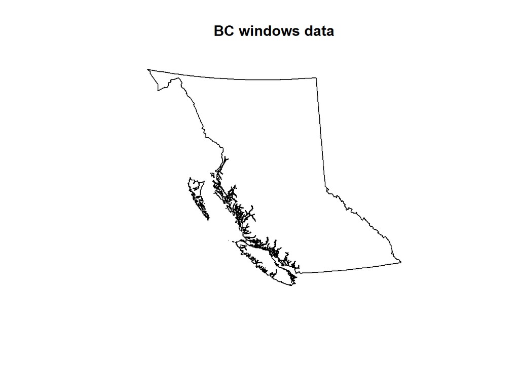

```r
load("data/BC_Covariates.Rda")

#observe windows
BC<-DATA
BC_win <- DATA$Window
BC_win <- as.owin(DATA$Window)
plot(BC_win,
      pch = 16,
      cols = "red",
      main = "BC windows data")
```

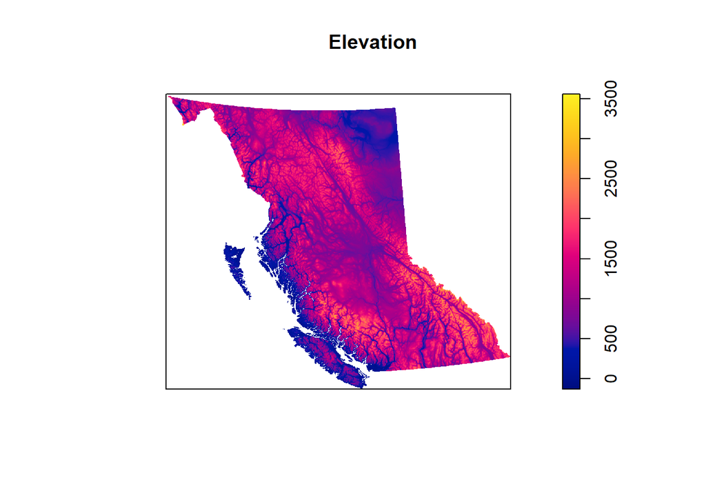

```r
#Elevation
plot(BC$Elevation, main = "Elevation")
```

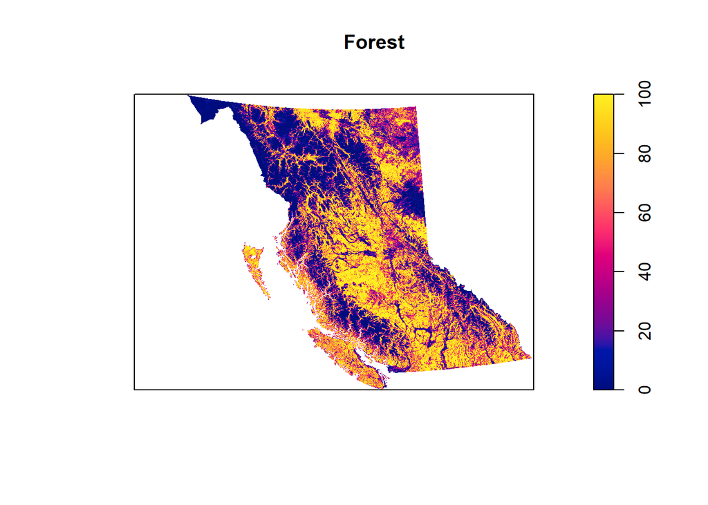

```r
#Forest
plot(BC$Forest, main = "Forest")
```

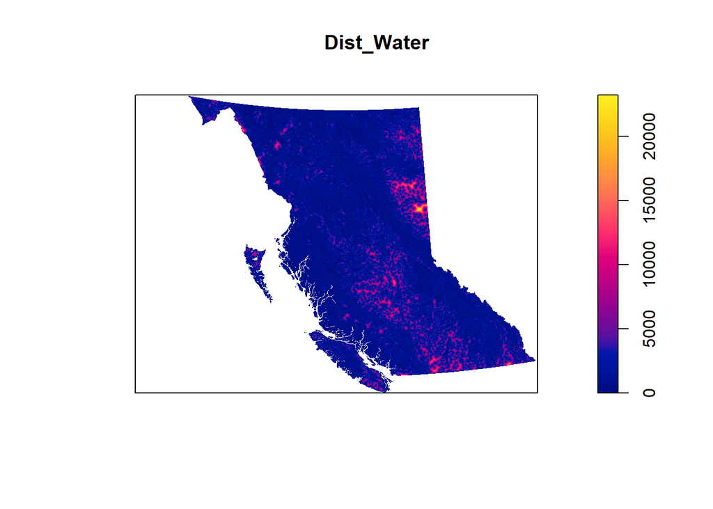

```r
#Dist_Water
plot(BC$Dist_Water, main = "Dist_Water")
```

## Spatial Dataset Conversion and Preparation

As the current format of the fungi data is not in a PPP class object, to facilitate subsequent analysis and plots, we would firstly convert it to the PPP, which would make subsequent plotting and analysis library much more accessible.

```r
# names(cleaned_asc_bc$decimalLongitude)
# class(cleaned_asc_bc$decimalLongitude)


# convert into ppp object
asc_data_ppp <- ppp(x = cleaned_asc_bc$decimalLongitude,
                     y = cleaned_asc_bc$decimalLatitude,
                     window = BC_win)
length(asc_data_ppp)
```

```
## [1] 5
```

```r
anyDuplicated(asc_data_ppp)
```

```
## [1] TRUE
```

```r
asc_data_ppp
```

```
## Planar point pattern: 400 points
## window: polygonal boundary
## enclosing rectangle: [273874.9, 1870573.4] x [369042.8, 1735666.4] units
## *** 100 illegal points stored in attr(,"rejects") ***
```

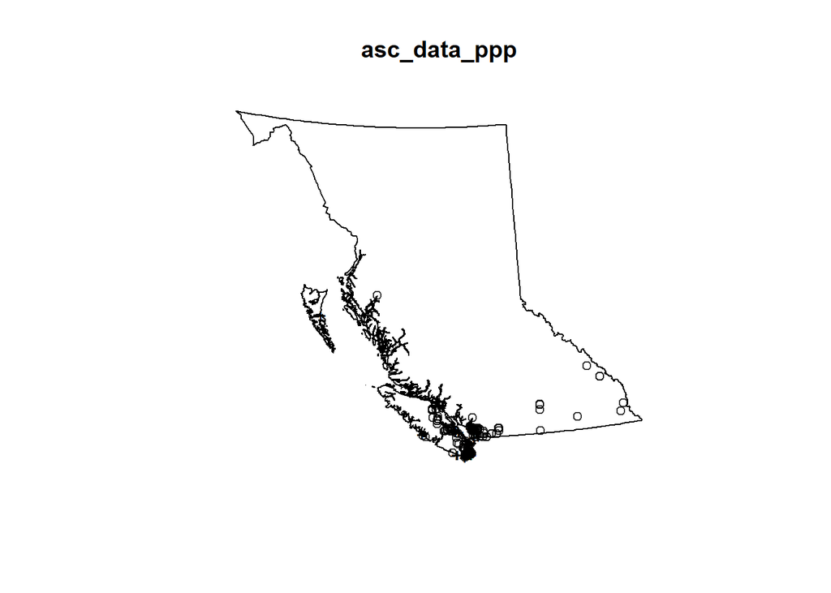

```r
# length(cleaned_asc_bc$decimalLongitude)
# length(cleaned_asc_bc$decimalLatitude)
# length(cleaned_asc_bc$species)
# length(marks(asc_data_ppp))
#
# marks(asc_data_ppp) <- factor(cleaned_asc_bc$species)
# length(cleaned_asc_bc$species)


plot(asc_data_ppp)
```

```r
#
# marks(asc_data_ppp) <- BC[[1]]$Region
```

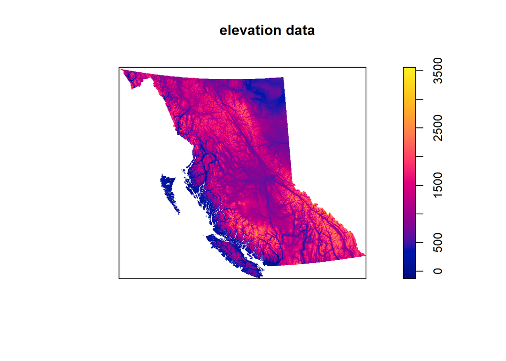

```r
plot(BC$Elevation, main = "elevation data")
```

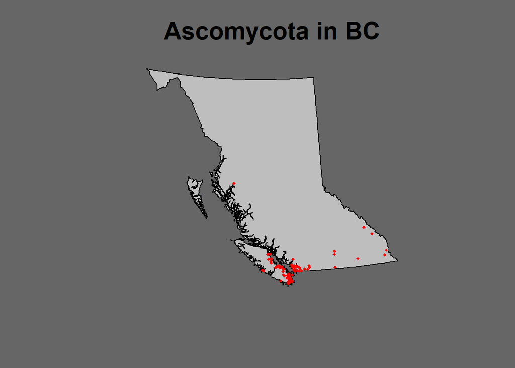

```r
plot(asc_data_ppp,
     which.marks = "species", # Which mark to use
     col = "grey", #The colour of the window
     cols = 'red', #The colours of the points
     cex = 0.6,
     pch = 18, # The plotting symbol
     main = "Ascomycota in BC", # The title
     par(bg="grey40", cex.main = 2),
     cex = 0.6,
     legend = T) # Turn of the legend depending on needs`
```

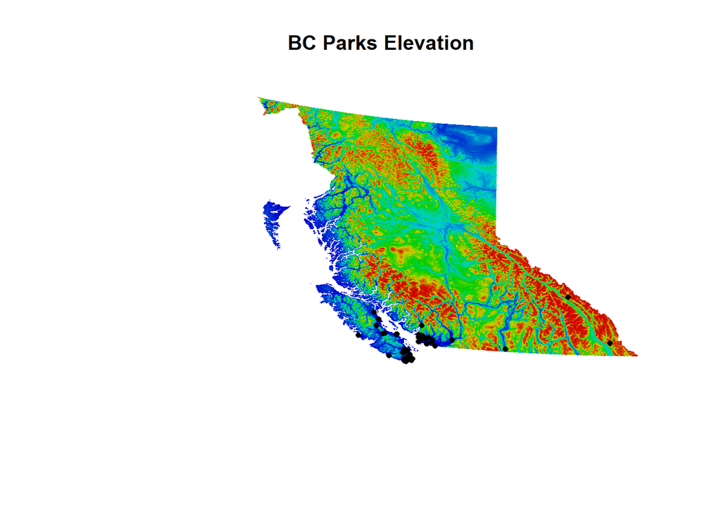

```r
col_pal <- rev(rainbow(100,end = 4/6))

fig <- persp(BC$Elevation, # source data
              theta = 10,
              phi = 40, # rotation
              expand = 0, # z-axis expansion
              border = NA, #remove grid borders
              apron = FALSE, #apron around edge
              shade = 0.3, # shading
              box = FALSE, # axes on/off
              main = "BC Parks Elevation", # title
              visible = TRUE, #Supporting calculations
              colmap = col_pal) # colour pallet

perspPoints(asc_data_ppp, Z = BC$Elevation, M = fig, pch = 16, cex = 0.7, col="black")
```

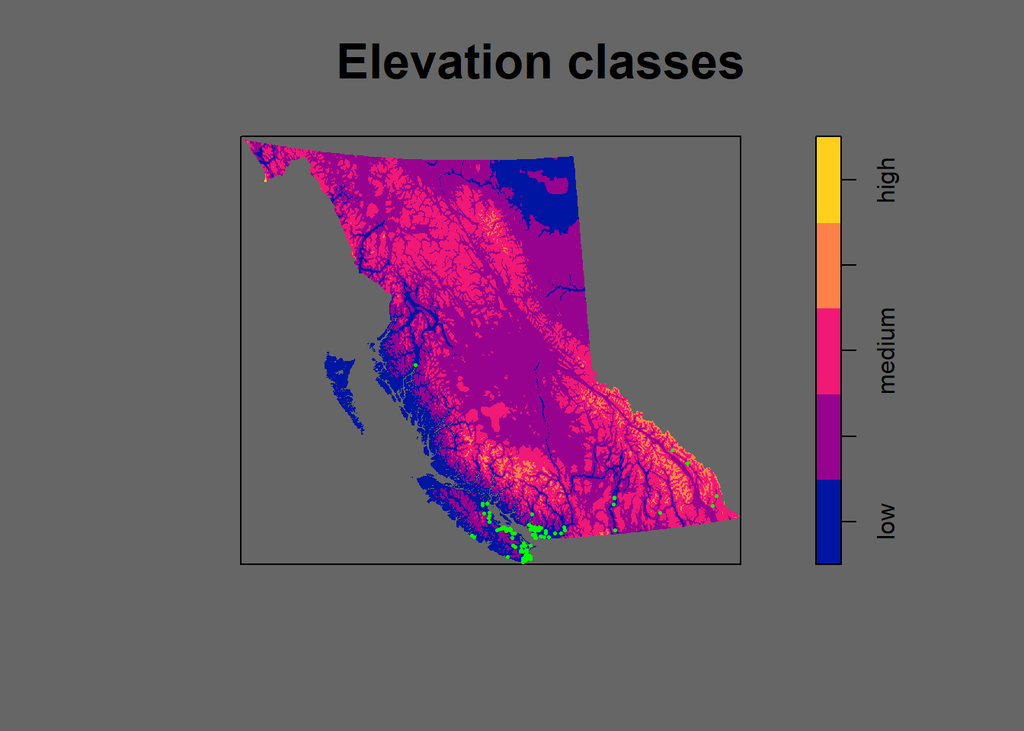

```r
plot(cut(BC$Elevation,5,
labels = c("low","low-medium","medium","medium-high","high")),
par(bg="grey40", cex.main = 2),
main = "Elevation classes")

points(asc_data_ppp, pch = 16, cex = 0.35, col="green")
```

```r
cut <- cut(BC$Elevation,5,
labels = c("low","low-medium","medium","medium-high","high"))
table(cut[asc_data_ppp]) #most in low elevation
```

[output not shown]

```r
# nn_dist <- nndist(asc_data_ppp)
# marks(asc_data_ppp) <- nn_dist
# plot(asc_data_ppp, main = "Ascomycota Distance",which.marks = "Dist", pch = 16)
BC$Elevation[asc_data_ppp]
```

```
##   [1]   91.271680   91.271680   23.397900   62.692406   51.428791  261.980282
##   [7]  261.980282  261.980282   74.498003   74.498003  510.926444   32.118248
##  [13]   62.814557   81.548294   81.548294   76.084493  706.409676   65.194619
##  [19]    8.000000  -35.179669  -35.179669  -35.179669  -35.179669   76.084493
##  [25]   76.084493   76.084493   32.118248   32.118248  195.284587   61.665185
##  [31]  206.588250   66.000000   65.619479  288.070603  288.070603  288.070603
##  [37]  288.070603  288.070603  355.967892  355.967892  355.967892  355.967892
##  [43]  355.967892  355.967892  355.967892  288.070603  288.070603  288.070603
##  [49]  288.070603  288.070603  288.070603  288.070603  288.070603  288.070603
##  [55]  288.070603  288.070603  430.115273  430.115273  288.070603  288.070603
##  [61]  355.967892  430.115273  430.115273  288.070603  288.070603  288.070603
##  [67]  288.070603  288.070603  288.070603  225.481611  225.481611  198.143926
##  [73]   81.126810  -35.053897  -35.053897   39.369451   39.369451  294.384024
##  [79]  -35.053897  -35.053897  -35.053897  -35.053897  -35.053897  -35.053897
##  [85]   71.801786  -35.053897  187.957696  187.957696  171.936613  167.107333
```

[output cut: 39 more lines]

```r
library("kdensity")
```

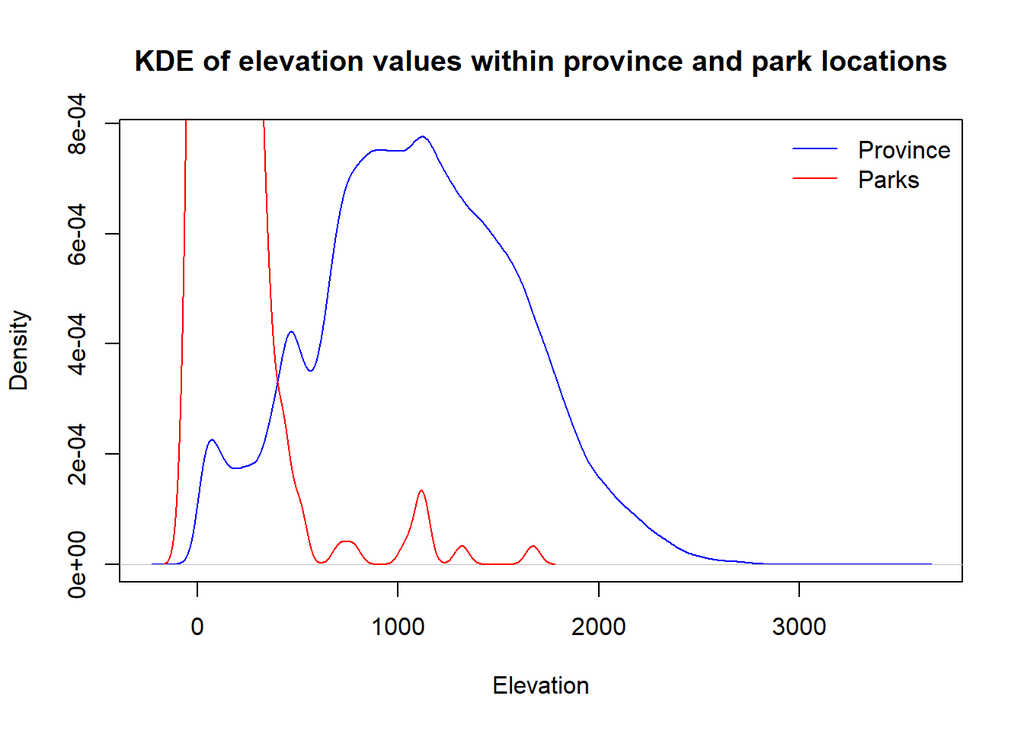

```r
asc_density <- density(BC$Elevation[asc_data_ppp])
province_density <- density(BC$Elevation$v, na.rm=T)


plot(province_density, main = "KDE of elevation values within province and park locations", xlab = "Elevation", ylab = "Density", col="blue")
lines(asc_density, col = "red")
legend("topright", legend = c("Province", "Parks"), lty = 1, col = c("blue", "red"), bty = "n")
```

```r
#
# plot(province_density, main = "KDE of elevation values within province and park locations", xlab = "Elevation", ylab = "Density", col="blue")
# lines(park_density, col = "red")
# legend("topright", legend = c("Province", "Parks"), lty = 1, col = c("blue", "red"), bty = "n")
```

## First Moment Descriptive Statistics

```r
intensity(asc_data_ppp)
```

```
## [1] 4.218242e-10
```

### Homogeneity Studies, Quadrat Test and Hotspot Analysis

Note that the intensity is a very small number. This is consistent with our plots above. There are not many points in the whole BC windows. Overwhelming majority of the points are spresely located in the BC. Let’s verify this with the Quadrat Count Plot.

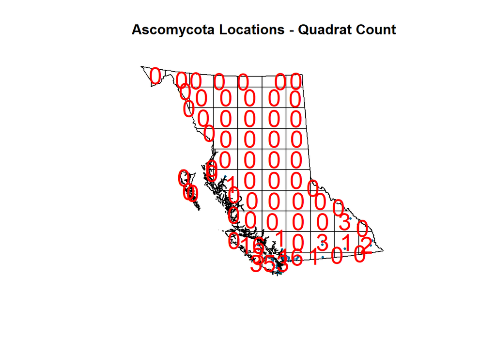

```r
Q <- quadratcount(asc_data_ppp,
                  nx = 10,
                  ny = 10)

#Plot the output
plot(asc_data_ppp,
     pch = 16,
     cex = 0.5,
     cols = "#046C9A",
     main = " Ascomycota Locations - Quadrat Count")
plot(Q, cex = 2, col = "red", add = T)
```

[figure not shown]

```r
plot(intensity(Q, image = T),
     main = "Beilschmiedia pendula intensity")

plot(asc_data_ppp,
     pch = 16,
     cex = 0.6,
     cols = "white",
     add = T)
plot(asc_data_ppp,
     pch = 16,
     cex = 0.5,
     cols = "black",
     add = T)
```

```r
#Quadrat test of homogeneity
quadrat.test(Q)
```

```
##
##  Chi-squared test of CSR using quadrat counts
##
## data:
## X2 = 23770, df = 63, p-value < 2.2e-16
## alternative hypothesis: two.sided
##
## Quadrats: 64 tiles (irregular windows)
```

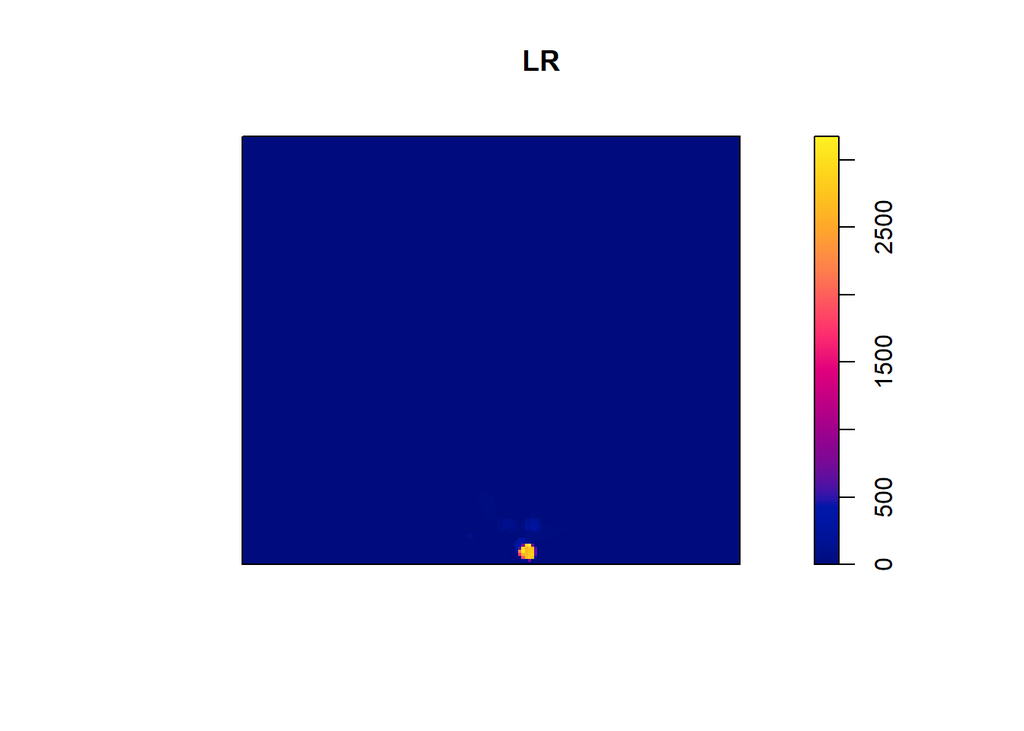

```r
R <- bw.ppl(asc_data_ppp)
LR <- scanLRTS(asc_data_ppp,r=R)
plot(LR)
```

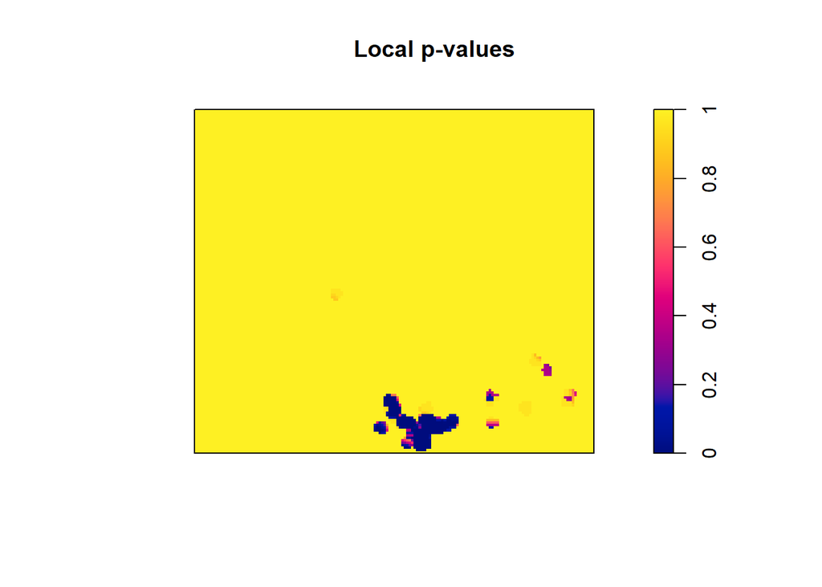

```r
pvals <- eval.im(pchisq(LR,
                        df = 1,
                        lower.tail = FALSE))


#Plot the output
plot(pvals, main = "Local p-values")
```

Once again, this has strongly verified the spatial inhomogeneity nature of the fungi distribution :

## Covariate Study

### Covariate Variable : Elevation

```
## tile
##          (-130,761]       (761,1.1e+03]  (1.1e+03,1.46e+03] (1.46e+03,3.56e+03]
##                 392                   2                   5                   1
```

[figure not shown]

```r
elev <- BC$Elevation
b <- quantile(elev,probs=(0:4)/4,type=2)
Zcut <- cut(elev,breaks=b)
V <- tess(image=Zcut)
quadratcount(asc_data_ppp,tess=V)
```

### Covariate Variable : Forest

```
## tile
##    (0,11.6] (11.6,50.2] (50.2,86.9]  (86.9,100]
##         196          94          81          29
```

[figure not shown]

```r
forest <- BC$Forest
b <- quantile(forest,probs=(0:4)/4,type=2)
Zcut <- cut(forest,breaks=b)
V <- tess(image=Zcut)
quadratcount(asc_data_ppp,tess=V)
```

### Covariate Variable : Distance to Water

```r
dist <- BC$Dist_Water
b <- quantile(dist,probs=(0:4)/4,type=2)
Zcut <- cut(dist,breaks=b)
V <- tess(image=Zcut)
quadratcount(asc_data_ppp,tess=V)
```

```
## tile
##             (0,483]       (483,1.1e+03]  (1.1e+03,2.18e+03] (2.18e+03,2.32e+04]
##                 213                  48                  37                  96
```

### Covariate Variable Observation

Observation :

- For Elevation Level :
  - It is obvious that the fungi is overwhelmingly correlated to the low elevation level.
  - The proportion of occurrence that appears in the lowest elevation sector accounts for more than 97% of the identified points.
- For Forest and Distance to Water :
  - It is observed that the fungi is correlated to both Forest and distance .
  - The proportion of occurrence that appears in the respective smallest sectors account for about 50% of the identified points.

## Second Moment Descriptives

# Results:

# Discussion:

# References: